# Oklahoma Paycheck Protection Program Analysis

Nicholas Jacob

7/08/2020

```r
library(tidyverse)
library(boot)
knitr::opts_chunk$set(echo = TRUE)
df <- read.csv("https://raw.githubusercontent.com/nurfnick/Data_Sets_For_Stats/master/OklahomaPPPLoanRecipents.csv")
```

## Oklahoma PPP

Since the data was released to the public I was interested in doing an analysis or atleast getting a project started so that someone else could finish it later!

The data loaded above was gathered from the website the Small Business Administration’s website https://www.sba.gov/funding-programs/loans/coronavirus-relief-options/paycheck-protection-program?utm_medium=email&utm_source=govdelivery#section-header-11 on 7/7/2020. Only data from Oklahoma will be exmained in this report. The excel file was cleaned to only include this data and uploaded to github for ease of access.

## Find Your Data: Project Part 1

Here is a sample of the data:

```r
df[0:10,] #displays first 10 rows and all columns
```

```
##          LoanRange                   BusinessName
## 1  a $5-10 million          A G EQUIPMENT COMPANY
## 2  a $5-10 million  ADVANTAGE ENERGY SERVICES LLC
## 3  a $5-10 million AMERICAN PIPING INSPECTION, IN
## 4  a $5-10 million                   AXH HOLDINGS
## 5  a $5-10 million        B & H CONSTRUCTION, LLC
## 6  a $5-10 million          BECCO CONTRACTORS INC
## 7  a $5-10 million     BENNETT CONSTRUCTION, INC.
## 8  a $5-10 million    BERENDSEN FLUID POWER, INC.
## 9  a $5-10 million            BOFS MANAGEMENT LLC
## 10 a $5-10 million                   CHC HOLDINGS
##                            Address          City State   Zip NAICSCode
## 1                 3401 W ALBANY ST  BROKEN ARROW    OK 74012    333132
## 2                   1010 N MAIN ST     MCALESTER    OK 74501    211120
## 3                     17110 E Pine         TULSA    OK 74037    238210
```

[output cut: 40 more lines]

There is a lot of data here. Unfortunately it does not currently meet the requirements of the project because there is only one true quantitative variable, JobsRetained. I am going to create a few columns trying to estimate the amount of money each loan was for by using the LoanRange column.

### Data Cleaning

```r
ranges <- unique(df['LoanRange'])

ranges
```

```
##                 LoanRange
## 1         a $5-10 million
## 45         b $2-5 million
## 290        c $1-2 million
## 775  d $350,000-1 million
## 2914   e $150,000-350,000
```

There are only five ranges present in the data. I’ll gather the smallest and lowest value for each loan and put it in our dataset as a column.

```r
df['MinLoan']<-case_when(df$LoanRange=='a $5-10 million'~5000000,
          df$LoanRange=='b $2-5 million'~2000000,
          df$LoanRange=='c $1-2 million'~1000000,
          df$LoanRange=='d $350,000-1 million'~350000,
          df$LoanRange=='e $150,000-350,000'~150000)


df['MaxLoan']<-case_when(df$LoanRange=='a $5-10 million'~10000000,
          df$LoanRange=='b $2-5 million'~5000000,
          df$LoanRange=='c $1-2 million'~2000000,
          df$LoanRange=='d $350,000-1 million'~1000000,
          df$LoanRange=='e $150,000-350,000'~350000)
```

I am just curious how much money came into the state. At a minimum

```r
sum(df$MinLoan)
```

```
## [1] 2533900000
```

2.5 billion dollars, not too shabby! That is the minimum, the max is

```r
sum(df$MaxLoan)
```

```
## [1] 6151250000
```

closer to 6 billion dollars. We don’t know the exact amount, but we know it is inbetween those dollar ammounts!

### Data Description

So now my data set meets the minimum requirements for the project. Let’s see if we can analize the varaibles.

```r
summary(df)
```

```
##                 LoanRange
##  a $5-10 million     :  44
##  b $2-5 million      : 245
##  c $1-2 million      : 485
##  d $350,000-1 million:2139
##  e $150,000-350,000  :3935
##
##
##                                                           BusinessName
##  COUNTRY STYLE HEALTH CARE, INC                                 :   2
##  FARMERS COOPERATIVE ASSOCIATION                                :   2
##  FIRST BAPTIST CHURCH                                           :   2
##  FIRST UNITED METHODIST CHURCH                                  :   2
##  FLEX-CHEM HOLDING COMPANY, LLC                                 :   2
##  LANDMARK OF MIDWEST CITY REHABILITATION AND NURSING CENTER, LLC:   2
##  (Other)                                                        :6836
##                            Address                City      State
##  14504 Hertz Quail Springs Pkwy:   8   OKLAHOMA CITY:1781   OK:6848
##  611 South Elm                 :   8   TULSA        :1464
##  2401 Tee Circle, Ste 103      :   7   EDMOND       : 328
##  1350 S BOULDER AVE            :   5   NORMAN       : 238
##  14504 HERTZ QUAIL SPRINGS PKWY:   4   BROKEN ARROW : 228
##  2500 N WALKER AVE             :   4   ENID         : 101
##  (Other)                       :6812   (Other)      :2708
##       Zip          NAICSCode                               BusinessType
##  Min.   :44301   Min.   :111140   Limited  Liability Company(LLC):2624
##  1st Qu.:73112   1st Qu.:332313   Corporation                    :2427
##  Median :73703   Median :517311   Subchapter S Corporation       :1025
##  Mean   :73682   Mean   :482078   Non-Profit Organization        : 457
##  3rd Qu.:74127   3rd Qu.:621340   Partnership                    :  93
##  Max.   :74966   Max.   :999990   Limited Liability Partnership  :  56
##                  NA's   :9        (Other)                        : 166
##                           RaceEthnicity           Gender            Veteran
##  American Indian or Alaska Native:  52   Female Owned: 402   Non-Veteran:1392
##  Asian                           :  28   Male Owned  :1949   Unanswered :5384
##  Black or African American       :  15   Unanswered  :4497   Veteran    :  72
##  Hispanic                        :  55
##  Unanswered                      :5523
##  White                           :1175
##
```

[output cut: 9 more lines]

```
##  BancFirst                          : 957   KS - 04:   1   Min.   : 150000
##  Arvest Bank                        : 483   OK - 01:2111   1st Qu.: 150000
##  BOKF, National Association         : 354   OK - 02: 716   Median : 150000
##  MidFirst Bank                      : 269   OK - 03:1378   Mean   : 370020
##  First United Bank and Trust Company: 243   OK - 04: 952   3rd Qu.: 350000
##  RCB Bank                           : 182   OK - 05:1689   Max.   :5000000
##  (Other)                            :4360   OK - 11:   1
##     MaxLoan
##  Min.   :  350000
##  1st Qu.:  350000
##  Median :  350000
##  Mean   :  898255
##  3rd Qu.: 1000000
##  Max.   :10000000
##
```

So this output is very intense! It went through every variable (and the case descriptors) and did some basic analysis of each.

For your paper you should carefully describe any variable you think you might use. For me that would include CD, this is the Congressional District. Ada is in the fourth congressional district, seen here:

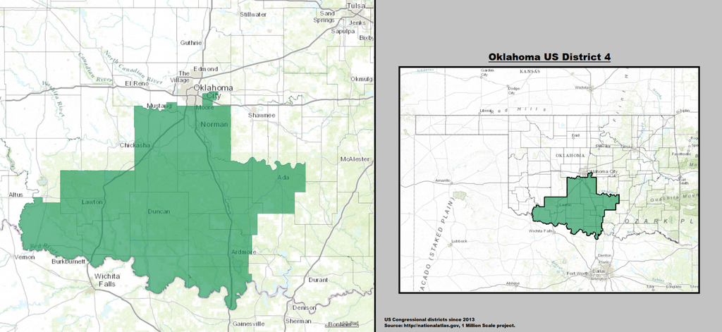

OK-04 Congressional District

They often talk about congress ‘bringing home the bacon’, let’s sperate out our district so we can analyze it later

```r
cd4 <- df[which(df$CD=='OK - 04'),]
summary(cd4)
```

```
##                 LoanRange
##  a $5-10 million     :  3
##  b $2-5 million      : 32
##  c $1-2 million      : 64
##  d $350,000-1 million:274
##  e $150,000-350,000  :579
##
##
##                                                           BusinessName
##  FIRST BAPTIST CHURCH                                           :  2
##  LANDMARK OF MIDWEST CITY REHABILITATION AND NURSING CENTER, LLC:  2
##  07 ENERGY CO LLC                                               :  1
##  3L INDUSTRIES, LLC                                             :  1
##  575 U, LLC                                                     :  1
##  A & J TRANSPORT, INC                                           :  1
##  (Other)                                                        :944
##                      Address               City     State         Zip
##  2401 Tee Circle, Ste 103:  7   NORMAN       :238   OK:952   Min.   :73004
##  1126 RAMBLING OAKS DR   :  3   OKLAHOMA CITY:230            1st Qu.:73071
##  1680 SW 86TH ST         :  3   LAWTON       : 92            Median :73139
##  198131 HIGHWAY 36       :  3   ADA          : 51            Mean   :73291
##  2815 SE 44TH ST         :  3   DUNCAN       : 51            3rd Qu.:73458
##  1025 E INDIAN HILLS RD  :  2   MOORE        : 51            Max.   :74865
##  (Other)                 :931   (Other)      :239
##    NAICSCode                               BusinessType
##  Min.   :111140   Limited  Liability Company(LLC):390
##  1st Qu.:238990   Corporation                    :328
##  Median :484220   Subchapter S Corporation       :142
##  Mean   :476851   Non-Profit Organization        : 47
##  3rd Qu.:621610   Partnership                    : 14
##  Max.   :999990   Sole Proprietorship            : 10
##  NA's   :1        (Other)                        : 21
##                           RaceEthnicity          Gender           Veteran
##  American Indian or Alaska Native:  4   Female Owned: 56   Non-Veteran:182
##  Asian                           :  3   Male Owned  :244   Unanswered :757
##  Black or African American       :  3   Unanswered  :652   Veteran    : 13
##  Hispanic                        :  3
##  Unanswered                      :778
##  White                           :161
##
```

[output cut: 9 more lines]

```
##  BancFirst                          :178   KS - 04:  0   Min.   : 150000
##  Arvest Bank                        :107   OK - 01:  0   1st Qu.: 150000
##  First United Bank and Trust Company: 77   OK - 02:  0   Median : 150000
##  Armstrong Bank                     : 59   OK - 03:  0   Mean   : 342174
##  Vision Bank, National Association  : 30   OK - 04:952   3rd Qu.: 350000
##  First Fidelity Bank                : 29   OK - 05:  0   Max.   :5000000
##  (Other)                            :472   OK - 11:  0
##     MaxLoan
##  Min.   :  350000
##  1st Qu.:  350000
##  Median :  350000
##  Mean   :  834716
##  3rd Qu.: 1000000
##  Max.   :10000000
##
```

So at a minimum:

```r
sum(cd4$MinLoan)
```

```
## [1] 325750000
```

325 million!